# Draft ERLP findings

- A full heatmap of responses can be found at https://measurementcanada.github.io/heatmap.html
- Maps associated with the targeted audience and results can be found at https://measurementcanada.github.io/erlp.html
- Responses from ASPs can be found at https://measurementcanada.github.io/asps.html

### Background

The Enforcement in Remote Locations Project (ERLP) is gathering data and information to help guide Measurement Canada enforcement activities at establishments located in remote areas with limited or no ASP service. The ERLP team sent out a consultation survey to 7870 establishments based on specific requirements of 1) located in rural postal codes, 2) have contact information derived from MC’s inspection database and 3) are operators of devices with mandatory inspection frequencies. The consultation period was from July 15 to August 7, 2020 via Google Forms.

### Responses

20 questions were posed as part of this exercise. These are summarized below.

A total of 791 respondents identified themselves as not being “remote” as defined in Question 6 below. As a result, tables for each question are broken down into results with only those who identify as remote (left) and all responses (right)

##### 1. Choose your language / Choisissez votre langue

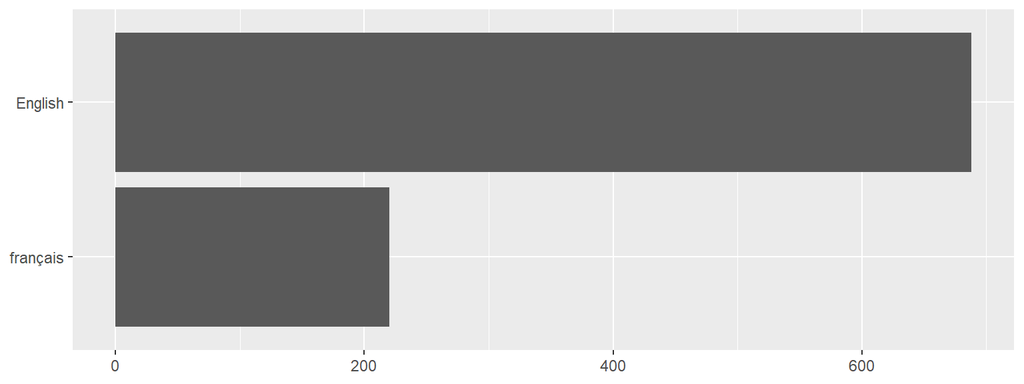

Filtering to show remote only

| Language | Responses | % |
| --- | --- | --- |
| English | 688 | 76% |
| français | 220 | 24% |

All responses

| Language | Responses | % |
| --- | --- | --- |
| English | 1256 | 73% |
| français | 471 | 27% |
| NA | 2 | 0% |

##### 2. Measurement Canada is responsible for ensuring accuracy in trade of measured goods, developing and enforcing the laws related to measurement accuracy, approving and inspecting measuring devices and investigating complaints of suspected inaccurate measurement. Before this contact, were you aware of our role in the Canadian marketplace?

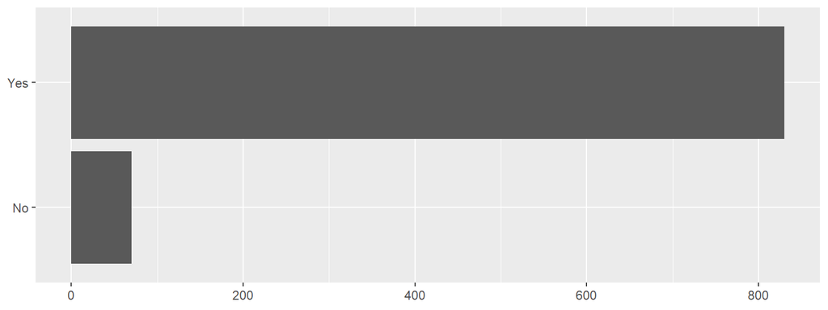

Filtering to show remote only

| Aware of role | Responses | % |
| --- | --- | --- |
| Yes | 830 | 92% |
| No | 70 | 8% |

All responses

| Aware of role | Responses | % |
| --- | --- | --- |
| Yes | 1585 | 92% |
| No | 117 | 7% |
| NA | 27 | 2% |

##### 3. Other than this, when was the last time you contacted or were contacted by a Measurement Canada representative?

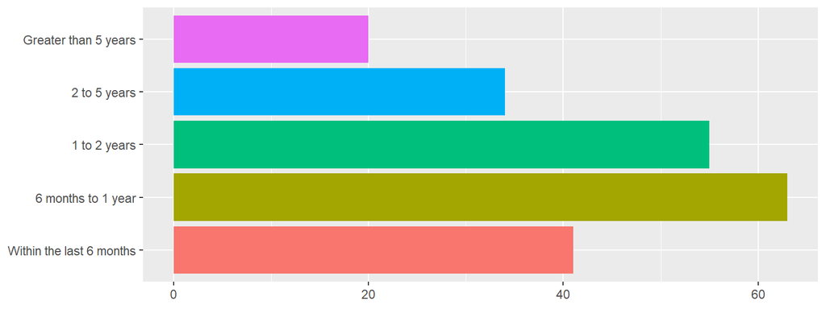

Filtering to show remote only

| Last contact | Responses | % |
| --- | --- | --- |
| Greater than 5 years | 20 | 9% |
| 2 to 5 years | 34 | 16% |
| 1 to 2 years | 55 | 26% |
| 6 months to 1 year | 63 | 30% |
| Within the last 6 months | 41 | 19% |

All responses

| Last contact | Responses | % |
| --- | --- | --- |
| Greater than 5 years | 46 | 3% |
| 2 to 5 years | 85 | 5% |
| 1 to 2 years | 135 | 8% |
| 6 months to 1 year | 122 | 7% |
| Within the last 6 months | 72 | 4% |
| NA | 1269 | 73% |

Note the significant amount of people who completed the survey but chose not to respond to this question (NA’s).

##### 4. As defined in the Weights and Measures Act, TRADE is considered as: The selling, purchasing, exchanging, consigning, leasing or providing of any commodity, right, facility or service on the basis of measure and includes the business of providing facilities for measuring. Does this definition apply to the transactions occurring in your business?

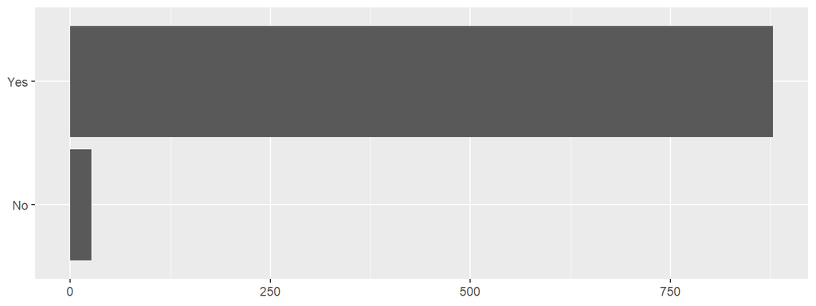

Filtering to show remote only

| In trade | Responses | % |
| --- | --- | --- |
| Yes | 878 | 97% |
| No | 26 | 3% |

All responses

| In trade | Responses | % |
| --- | --- | --- |
| Yes | 1642 | 95% |
| No | 69 | 4% |
| NA | 18 | 1% |

##### 5. An authorized service provider (ASP) is an organization recognized by Measurement Canada to inspect and certify measuring devices. All ASPs must complete training and meet strict criteria before they can do so. Who do you use to inspect your devices?

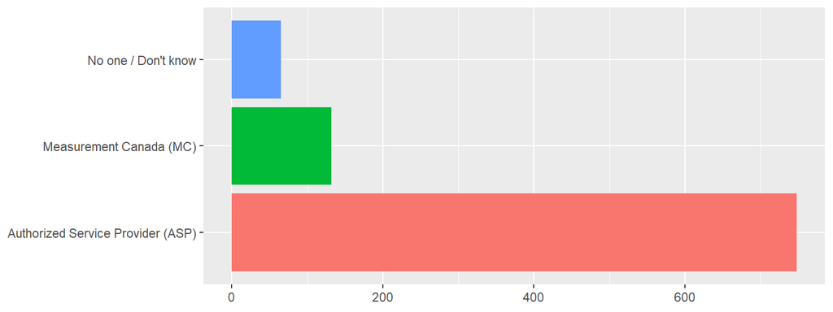

Filtering to show remote only

| Who inspects | Responses | % |
| --- | --- | --- |
| No one / Don’t know | 65 | 7% |
| Measurement Canada (MC) | 132 | 14% |
| Authorized Service Provider (ASP) | 748 | 79% |

All responses

| Who inspects | Responses | % |
| --- | --- | --- |
| No one / Don’t know | 118 | 6% |
| Measurement Canada (MC) | 291 | 16% |
| Authorized Service Provider (ASP) | 1400 | 77% |
| NA | 17 | 1% |

##### 6. For the purposes of this survey, REMOTE LOCATION is defined as: A business that is not easily accessible and therefore provides challenges and/or prohibitive costs for testing the device, including distance, transportation of test equipment or handling of test product. Does your business fit this definition of a remote location?

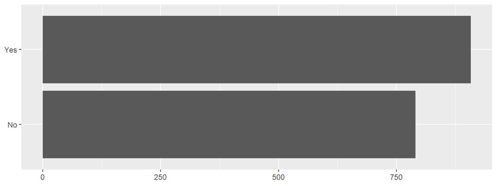

All responses

| Remote estab | Responses | % |
| --- | --- | --- |
| Yes | 908 | 53% |
| No | 791 | 46% |
| NA | 30 | 2% |

##### 7. Please describe your principal business line(s)

Temporarily removed these responses.

##### 8. What type of weighing (scales) or measuring devices (petroleum dispensers, metering devices or other) do you use in trade? Please check all that apply.

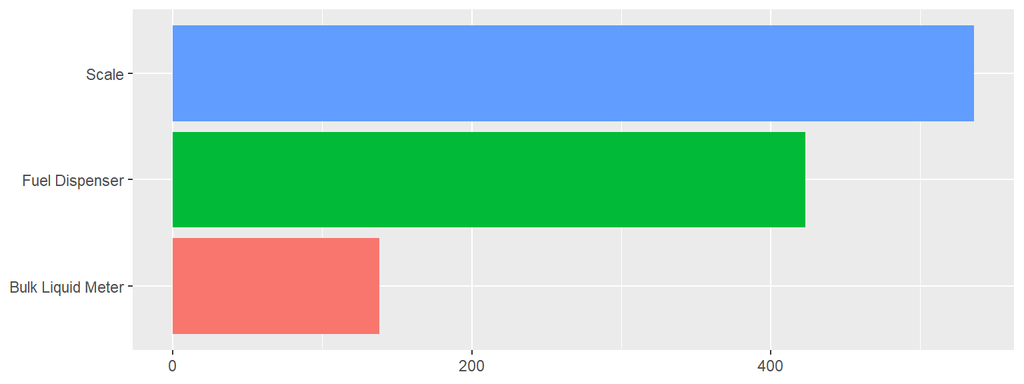

Filtering to show remote only

| Device type | Responses | % |
| --- | --- | --- |
| Scale | 536 | 49% |
| Fuel Dispenser | 423 | 39% |
| Bulk Liquid Meter | 138 | 13% |

All responses

| Device type | Responses | % |
| --- | --- | --- |
| Scale | 1033 | 50% |
| Fuel Dispenser | 758 | 37% |
| Bulk Liquid Meter | 243 | 12% |
| NA | 39 | 2% |

##### 9. When operational, please estimate how may times a day that you measure product using any / all of the devices listed above?

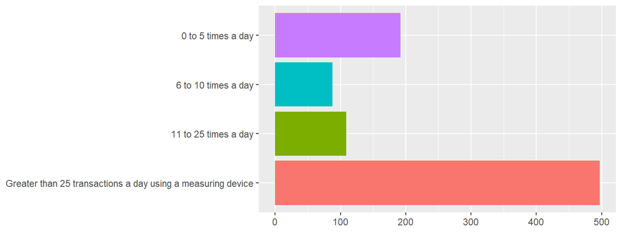

Filtering to show remote only

| Transactions | Responses | % |
| --- | --- | --- |
| 0 to 5 times a day | 192 | 22% |
| 6 to 10 times a day | 88 | 10% |
| 11 to 25 times a day | 109 | 12% |
| Greater than 25 transactions a day using a measuring device | 497 | 56% |

All responses

| Transactions | Responses | % |
| --- | --- | --- |
| 0 to 5 times a day | 360 | 21% |
| 6 to 10 times a day | 166 | 10% |
| 11 to 25 times a day | 219 | 13% |
| Greater than 25 transactions a day using a measuring device | 932 | 54% |
| NA | 52 | 3% |

##### 10. Are there other establishments in your trade sector, or with the same device types, that operate in the same general area as your establishment?

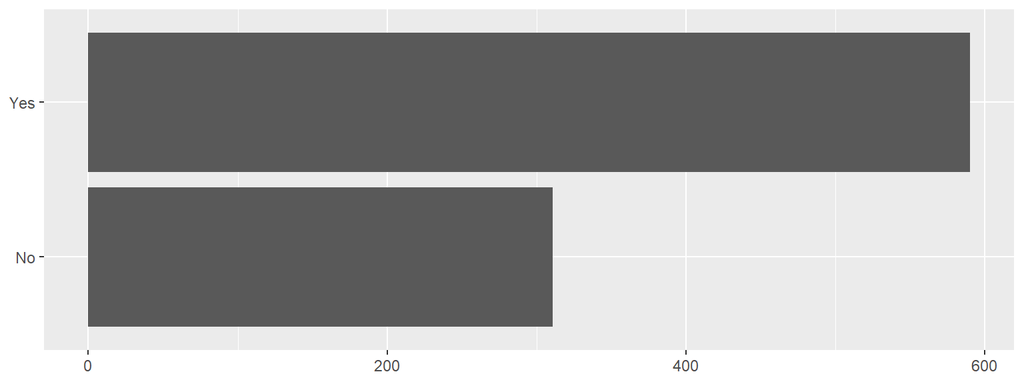

Filtering to show remote only

| Other estabs | Responses | % |
| --- | --- | --- |
| Yes | 590 | 65% |
| No | 311 | 35% |

All responses

| Other estabs | Responses | % |
| --- | --- | --- |
| Yes | 1163 | 67% |
| No | 537 | 31% |
| NA | 29 | 2% |

##### 11. Do you trade in the following sectors (please check all that apply)

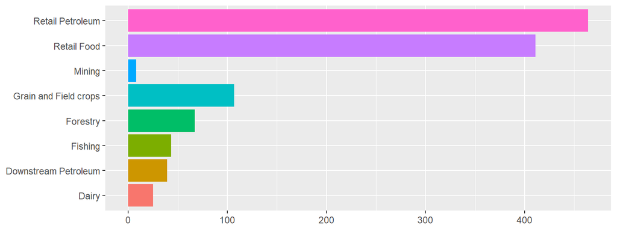

Filtering to show remote only

| Trade sector | Responses | % |
| --- | --- | --- |
| Retail Petroleum | 464 | 40% |
| Retail Food | 411 | 35% |
| Mining | 8 | 1% |
| Grain and Field crops | 107 | 9% |
| Forestry | 67 | 6% |
| Fishing | 43 | 4% |
| Downstream Petroleum | 39 | 3% |
| Dairy | 25 | 2% |

All responses

| Trade sector | Responses | % |
| --- | --- | --- |
| Retail Petroleum | 826 | 37% |
| Retail Food | 730 | 33% |
| Mining | 21 | 1% |
| Grain and Field crops | 270 | 12% |
| Forestry | 116 | 5% |
| Fishing | 79 | 4% |
| Downstream Petroleum | 79 | 4% |
| Dairy | 46 | 2% |
| NA | 44 | 2% |

##### 12. At the present time, device owners are required to have their scales, gas pumps and other weighing and measuring equipment inspected within a prescribed mandatory inspection frequency in eight sectors: dairy, downstream petroleum, fishing, forestry, grain and field crops, mining, retail food, and retail petroleum. Are the devices you operate inspected within the required frequency?

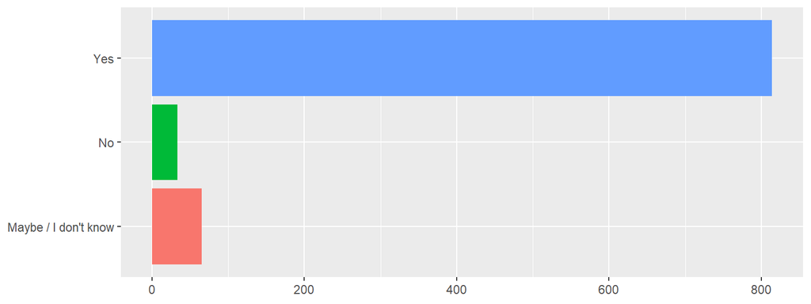

Filtering to show remote only

| Compliant | Responses | % |
| --- | --- | --- |
| Yes | 814 | 89% |
| No | 33 | 4% |
| Maybe / I don’t know | 65 | 7% |

All responses

| Compliant | Responses | % |
| --- | --- | --- |
| Yes | 1584 | 91% |
| No | 48 | 3% |
| Maybe / I don’t know | 90 | 5% |
| NA | 21 | 1% |

##### 13. Describe what procedures (if any) you have to check that your devices are accurate and how often?

Temporarily removed these responses.

##### 14. What obstacles have you faced when trying to get your devices inspected?

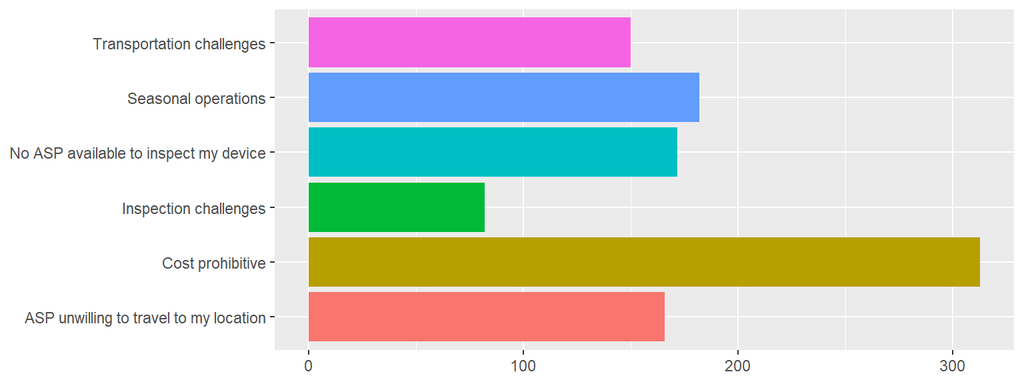

Filtering to show remote only

| Obstacles | Responses | % |
| --- | --- | --- |
| Transportation challenges | 150 | 14% |
| Seasonal operations | 182 | 17% |
| No ASP available to inspect my device | 172 | 16% |
| Inspection challenges | 82 | 8% |
| Cost prohibitive | 313 | 29% |
| ASP unwilling to travel to my location | 166 | 16% |

All responses

| Obstacles | Responses | % |
| --- | --- | --- |
| Transportation challenges | 156 | 7% |
| Seasonal operations | 275 | 13% |
| No ASP available to inspect my device | 216 | 10% |
| Inspection challenges | 116 | 5% |
| Cost prohibitive | 388 | 18% |
| ASP unwilling to travel to my location | 191 | 9% |
| NA | 813 | 38% |

##### 15. Is your device is portable and therefore possible to send away for inspection?

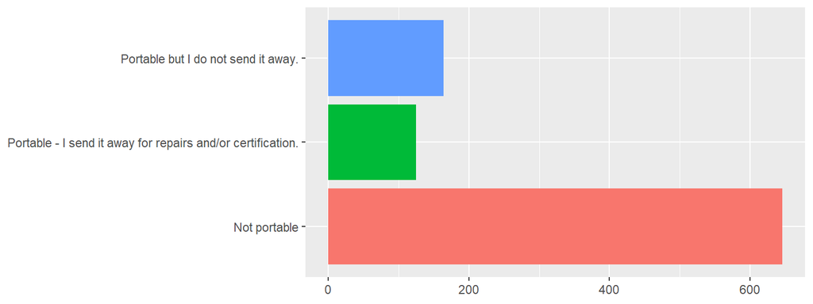

Filtering to show remote only

| Portability | Responses | % |
| --- | --- | --- |
| Portable but I do not send it away. | 164 | 18% |
| Portable - I send it away for repairs and/or certification. | 125 | 13% |
| Not portable | 646 | 69% |

All responses

| Portability | Responses | % |
| --- | --- | --- |
| Portable but I do not send it away. | 315 | 17% |
| Portable - I send it away for repairs and/or certification. | 191 | 11% |
| Not portable | 1252 | 69% |
| NA | 49 | 3% |

##### 16. As part of this study, we’d like to know your concerns and recommendations for ensuring devices in remote locations meet the regulatory requirements for mandatory re-verification. Please let us know of any other considerations that you feel are important. (eg. time between inspections, costs, availability of ASP)

Temporarily removed these responses.

#### Items 17, 18, and 19 skipped (in this report) as they contain personal information.

##### 20. Would you like a Measurement Canada Official to contact you regarding this feedback?

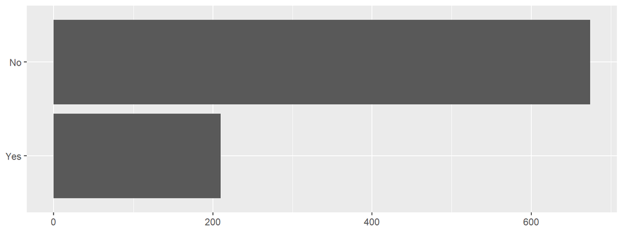

Filtering to show remote only

| Contact them | Responses | % |
| --- | --- | --- |
| Yes | 210 | 24% |
| No | 674 | 76% |

All responses

| Contact them | Responses | % |
| --- | --- | --- |
| Yes | 300 | 17% |
| No | 1373 | 79% |
| NA | 56 | 3% |